# Classification case study: H1N1 flu vaccine data

Umut Arslan

22 mars, 2021

## Problem description

We will use the data to predict the likelihood of people taking the vaccine. The reason for the predictions is to see what variables weight in the most, if we can find those we could probably increase the likelihood of more people vaccinating themselves

## Brief introduction to the data

The data consists of a subset of the data collected through The National 2009 H1N1 Flu Survey conducted in the United States. The target population for the NHFS was all persons 6 months or older living in the United States at the time of the interview. Data from the NHFS were used to produce timely estimates of vaccination coverage rates for both the monovalent pH1N1 and trivalent seasonal influenza vaccines.

## Data exploration

```r
##########################################
#Load data (with missingness)
##########################################
load("test_predictors.RData")
load("train_predictors_outcome.RData")


##########################################
#Explore data
##########################################
```

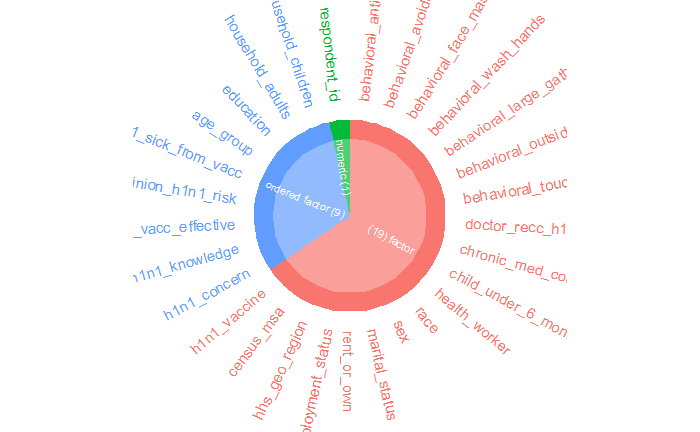

```r
#View distribution of variable classes
show_plot(inspect_types(train_predictors_outcome))
```

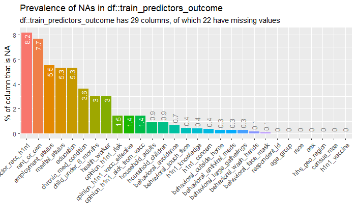

```r
#View distribution of missing values
show_plot(inspect_na(train_predictors_outcome))
```

We can see that we have a couple of variables with relatively high proportion of missingness, some with modern missingness, some with relatively low missingness and seven of the variables have no missing values. If we look at the data stratified on the outcome we can see if the missingness pattern seem to differ between the two outcome classes.

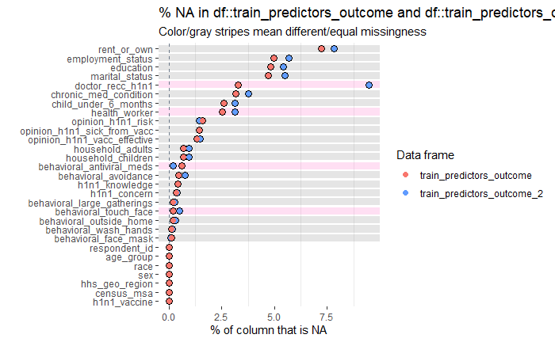

```r
#View distribution of missing values stratified on outcome
show_plot(inspect_na(train_predictors_outcome %>% filter(h1n1_vaccine  == "Yes"), train_predictors_outcome %>% filter(h1n1_vaccine  == "No")))
```

Most of the variables the pattern is similar, but for doctor_recc_h1n1 there are more then significant diffrecense. Some of the other variables (if u look on the top of the graph) also have a diffrence between them but the differences between thoes are not as noticeable as doctor_recc_h1n1

## Analysis

### Impute missing data

Since we have missing values (NAs) in our data, we will impute these. We will use an easy to implement single imputation method based on the K nearest neighbor method.

```r
########################################################################
# IMPUTE MISSING DATA
########################################################################

#Set a random seed, in this way we can replicate the exact splits later on if needed
set.seed(82734)

#Make a recipe for how the imputation will be done (specify the imputation model)
  impute_recipe <- recipe(h1n1_vaccine ~ ., data = train_predictors_outcome) %>%
  step_knnimpute(all_predictors(), neighbors = 3)
  impute_prep <- prep(impute_recipe, training = train_predictors_outcome) #Prep the train_predictors_outcome data using the imputation recipe


  #train_imp <- bake(impute_prep, train_predictors_outcome), Bake (compute/retrieve) the imputed data by using the prep above on the data
  #test_imp <- bake(impute_prep, test_predictors), Bake (compute/retrieve) the imputed data by using the prep above on the data
  #save(test_imp, file = "test_imp.RData"), Save for later
  #save(train_imp, file = "train_imp.RData"), Save for later


  #Because i already ran the codes i can just load the data
  load("train_imp.RData")
  load("test_imp.RData")
```

[figure not shown]

As u can see now we have zero missing values.

We started by splitting the data into a training and a test set and here we will take the training data and split it further

```r
########################################################################
# CREATE CROSS-VALIDATION FOLDS FOR MODEL EVALUATION/COMPARISON
########################################################################
#Prepare for 10-fold cross-validation, observations selected into folds with random
#sampling stratified on outcome
set.seed(877)
folds <- vfold_cv(train_imp, v = 10, strata = h1n1_vaccine)
```

### Evaluation metrics

Decide which performance measures to compute.

```r
########################################################################
# EVALUATION METRICS
########################################################################
#Which metrics should be computed?
my_metrics <- metric_set(roc_auc, precision, recall, specificity, accuracy, bal_accuracy, f_meas)
```

### Data preprocessing

In this step we prepare the data for analysis. Since in our case the outcome variable is pretty unbalanced we will downsample the majority class, h1n1_vaccine,

```r
########################################################################
# CREATE RECIPE FOR PREPROCESSING DATA
########################################################################
#Create recipe for preprocessing data: undersampling majority class, categorical variables into dummy variables etc
train_rec <-
    recipe(h1n1_vaccine ~ ., data = train_imp) %>%
    update_role(respondent_id, new_role = "ID") %>%
    step_normalize(all_numeric()) %>% #Center and scale all numeric variables
    step_dummy(all_nominal(), -all_outcomes()) %>% #Recode all factors, except outcome, to dummy variables
    themis::step_downsample(h1n1_vaccine) #Downsample the majority class to have a more balanced outcome
```

### Modelling

We will analyze the data using four different methods: Logistic regression, Penalized logistic regression (LASSO), K nearest neighbors and Random forest

#### LOGISTIC REGRESSION

Here, when fitting the logistic regression model we will do no model selection or include any interaction etc. We simply fit a model where we include all predictors and evaluate this by 10-fold cross-validation.

```r
########################################################################
# MODELLING
########################################################################
########################################
# MODEL 1: Logistic regression
########################################
#Model specification
lr_mod <-
  logistic_reg() %>%
  set_engine("glm")

#Work flow: Which model to use and how data should be preprocessed
lr_wflow <-
  workflow() %>%
  add_model(lr_mod) %>%
  add_recipe(train_rec)

#Use the workflow and folds object to fit model on cross-validation resamples
lr_fit_rs <-
  lr_wflow %>%
  fit_resamples(folds, metrics = my_metrics, control = control_resamples(save_pred = TRUE))

#Get mean out-of-sample performance measures
lr_metrics <- collect_metrics(lr_fit_rs)
lr_metrics
```

| .metric | .estimator | mean | n | std_err | .config |
| --- | --- | --- | --- | --- | --- |
| accuracy | binary | 0.7686582 | 10 | 0.001843450 | Preprocessor1_Model1 |
| bal_accuracy | binary | 0.7530965 | 10 | 0.004160683 | Preprocessor1_Model1 |
| f_meas | binary | 0.5713248 | 10 | 0.004561712 | Preprocessor1_Model1 |
| precision | binary | 0.4711066 | 10 | 0.002861242 | Preprocessor1_Model1 |
| recall | binary | 0.7260353 | 10 | 0.009043965 | Preprocessor1_Model1 |
| roc_auc | binary | 0.8251231 | 10 | 0.003212692 | Preprocessor1_Model1 |
| spec | binary | 0.7801576 | 10 | 0.001996959 | Preprocessor1_Model1 |

#### HYPERPARAMETER TUNING

In some modelling situations we need to select the value for one or several so called hyperparameters. The next model i choose to predict with is Penalized logistic regression (LASSO)

```r
############################################################
#CREATE CROSS-VALIDATION FOLDS FOR HYPERPARAMETER TUNING
###########################################################
#Prepare for hyperparameter selection by 10-fold cross-validation, observations selected into folds with random
#sampling stratified on outcome
set.seed(89)
tune_folds <- vfold_cv(train_imp, v = 10, strata = h1n1_vaccine)

#Set metric for choosing hyperparameter
roc_res <- metric_set(roc_auc)
```

#### PENALIZED LOGISTIC REGRESSION (LASSO)

Penalized logistic regression, here in the form of LASSO, shrinks coefficients for irrelevant variables towards zero. How much shrinkage is done depends on the size of the penalty parameter. In this way a kind of variable selection is performed since variables that are only weakly related to the outcome will have less impact when predicting the outcome.

```r
################################################
# MODEL 2: Penalized logistic regression (LASSO)
################################################

#Model specification
penlr_mod <-
    logistic_reg(mixture = 1, penalty = tune()) %>% #Specify that we want to tune the penalty parameter
    set_engine("glmnet") %>%
    set_mode("classification")

#Set up workflow
penlr_wflow <-
    workflow() %>%
    add_model(penlr_mod) %>%
    add_recipe(train_rec)

#Get a parameter object for our data and model specification. Contains information about possible values, ranges, types etc.
  penlr_param <-
    penlr_wflow %>%
    parameters() %>%
    finalize(train_imp)

#Look at the range for the penalty parameter
penlr_param%>% pull_dials_object("penalty")
```

```
Amount of Regularization (quantitative)
Transformer:  log-10
Range (transformed scale): [-10, 0]
```

```r
#Already tuned the code, will load it instead.
load("penlr_tune.RData")

#Store the best penalty value
penlr_best_param <- select_best(penlr_tune, "roc_auc")

#Set up the final workflow using the best penalty value
final_penlr_wflow <-
     penlr_wflow %>%
     finalize_workflow(penlr_best_param)

#Fit the final model on the cross-validation folds set up for model evaluation/comparison
penlr_fit_rs <-
     final_penlr_wflow %>%
     fit_resamples(folds, metrics = my_metrics, control = control_resamples(save_pred = TRUE))

#Get mean out-of-sample performance measures
penlr_metrics <- collect_metrics(penlr_fit_rs)
   penlr_metrics
```

| .metric | .estimator | mean | n | std_err | .config |
| --- | --- | --- | --- | --- | --- |
| accuracy | binary | 0.7707054 | 10 | 0.001706012 | Preprocessor1_Model1 |
| bal_accuracy | binary | 0.7522513 | 10 | 0.003772940 | Preprocessor1_Model1 |
| f_meas | binary | 0.5715372 | 10 | 0.004174345 | Preprocessor1_Model1 |
| precision | binary | 0.4738971 | 10 | 0.002680981 | Preprocessor1_Model1 |
| recall | binary | 0.7201607 | 10 | 0.008283899 | Preprocessor1_Model1 |
| roc_auc | binary | 0.8256930 | 10 | 0.003363932 | Preprocessor1_Model1 |
| spec | binary | 0.7843419 | 10 | 0.001975085 | Preprocessor1_Model1 |

#### K NEAREST NEIGHBORS

The most important hyperparameter is the number of neighbors used in the fit. Another hyperparameter is the kernel, which decides how much weight a neighboring observation is given depending on its distance from the observation of interest. Here, we will go with default values on all hyperparameters except the number of neighbors.

```r
################################################
# MODEL 3: Nearest neighbors
################################################

#Model specification
knn_mod <-
     nearest_neighbor(neighbors = tune()) %>% #Specify that we want to tune the neighbors parameter
     set_engine("kknn") %>%
     set_mode("classification")

#Work flow: Which model to use and how data should be preprocessed
knn_wflow <-
     workflow() %>%
     add_model(knn_mod) %>%
     add_recipe(train_rec)


#Get a parameter object for our data and model specification
knn_param <-
     knn_wflow %>%
     parameters() %>%
     finalize(train_imp)

#Look at the range for the neighbor parameter
knn_param%>% pull_dials_object("neighbors")
```

```
# Nearest Neighbors (quantitative)
Range: [1, 15]
```

```r
#Update the range for possible neighbor values
knn_param <-
  knn_wflow %>%
  parameters() %>%
  update(neighbors = neighbors(c(1, 500))) %>%
  finalize(train_imp)

#Look at the updated range for the neighbor parameter
knn_param%>% pull_dials_object("neighbors")
```

```
# Nearest Neighbors (quantitative)
Range: [1, 500]
```

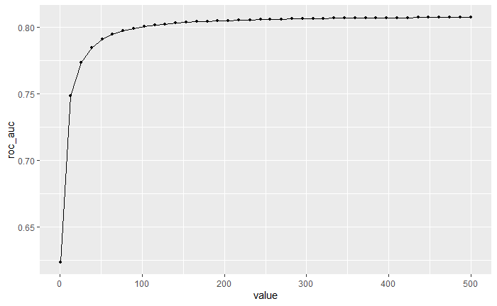

```r
#Already tuned the code, will load it instead.
load("knn_tune.RData")

#View plot of number of neighbors vs. AUROC
autoplot(knn_tune) + theme(legend.position = "top")
```

```r
#Store the best neighbor value
knn_best_param <- select_best(knn_tune, "roc_auc")

#Set up the final workflow using the best neighbor value
final_knn_wflow <-
  knn_wflow %>%
  finalize_workflow(knn_best_param)

#Fit the final model on the cross-validation folds set up for model evaluation/comparison
knn_fit_rs <-
  final_knn_wflow %>%
  fit_resamples(folds, metrics = my_metrics, control = control_resamples(save_pred = TRUE))

#Get mean out-of-sample performance, measured as accuracy and area under the receiver operator curve (AUROC)
knn_metrics <- collect_metrics(knn_fit_rs)
knn_metrics
```

| .metric | .estimator | mean | n | std_err | .config |
| --- | --- | --- | --- | --- | --- |
| accuracy | binary | 0.7669124 | 10 | 0.003588204 | Preprocessor1_Model1 |
| bal_accuracy | binary | 0.7339703 | 10 | 0.004441396 | Preprocessor1_Model1 |
| f_meas | binary | 0.5523609 | 10 | 0.005783672 | Preprocessor1_Model1 |
| precision | binary | 0.4668254 | 10 | 0.005580148 | Preprocessor1_Model1 |
| recall | binary | 0.6766871 | 10 | 0.007654156 | Preprocessor1_Model1 |
| roc_auc | binary | 0.8073428 | 10 | 0.004205114 | Preprocessor1_Model1 |
| spec | binary | 0.7912536 | 10 | 0.003884143 | Preprocessor1_Model1 |

#### RANDOM FOREST

Random forest is an ensemble method that grows T descision trees where each tree is fitted using a bootstrap sample. A bootstrap sample is a random sample of the data, of the same size as the data, sampled with replacement. At each candidate split when growing a tree, a random subset of the predictors is considered for the split. A prediction is subsequently made by taking the majority vote of all T trees, that is the most frequently predicted class among all T trees. Below, we will tune the models in terms of both the number of trees and number of randomly selected predictors.

```r
################################################
# MODEL 4: Random forest
################################################

#Preprocessing without creating dummies
train_rec_rf <-
      recipe(h1n1_vaccine ~ ., data = train_imp) %>%
      update_role(respondent_id, new_role = "ID") %>%
      step_normalize(all_numeric()) %>%
      themis::step_downsample(h1n1_vaccine)

#Model specification
rf_mod <-
  rand_forest(mtry = tune(), trees = tune()) %>% #Specify that we want to tune both the mtry and trees parameters
  set_engine("ranger", importance = "impurity") %>%
  set_mode("classification")

#Work flow: Which model to use and how data should be preprocessed
rf_wflow <-
  workflow() %>%
  add_model(rf_mod) %>%
  add_recipe(train_rec_rf)

#Get a parameter object for our data and model specification, where we also update the ranges of mtry and trees
rf_param <-
  rf_wflow %>%
  parameters() %>%
  update(mtry = mtry(c(1, 16))) %>%
  update(trees = trees(c(500, 1500))) %>%
  finalize(train_imp)


#Already tuned the code, will load it instead.
load("rf_tune.RData")


#Store the best hyperparameter combination
rf_best_param <- select_best(rf_tune, "roc_auc")

#Set up the final workflow using the best hyperparameter values
final_rf_wflow <-
  rf_wflow %>%
  finalize_workflow(rf_best_param)

#Fit the final model on the cross-validation folds set up for model evaluation/comparison
rf_fit_rs <-
  final_rf_wflow %>%
  fit_resamples(folds, metrics = my_metrics, control = control_resamples(save_pred = TRUE))

#Get mean out-of-sample performance, measured as accuracy and area under the receiver operator curve (AUROC)
rf_metrics <- collect_metrics(rf_fit_rs)
rf_metrics
```

| .metric | .estimator | mean | n | std_err | .config |
| --- | --- | --- | --- | --- | --- |
| accuracy | binary | 0.7635671 | 10 | 0.002473253 | Preprocessor1_Model1 |
| bal_accuracy | binary | 0.7537218 | 10 | 0.004182563 | Preprocessor1_Model1 |
| f_meas | binary | 0.5695909 | 10 | 0.004717483 | Preprocessor1_Model1 |
| precision | binary | 0.4644894 | 10 | 0.003621101 | Preprocessor1_Model1 |
| recall | binary | 0.7366031 | 10 | 0.008912925 | Preprocessor1_Model1 |
| roc_auc | binary | 0.8247265 | 10 | 0.003784158 | Preprocessor1_Model1 |
| spec | binary | 0.7708405 | 10 | 0.003013416 | Preprocessor1_Model1 |

## Results

Table 3. Model performance based on 10-fold CV on imputed training data (n = 6 676)

| Metric | Measure | Log_reg | Pen_log_reg | KNN | RF |
| --- | --- | --- | --- | --- | --- |
| roc_auc | mean | 0.8251231 | 0.8256930 | 0.8073428 | 0.8247265 |
| roc_auc | std_err | 0.0032127 | 0.0033639 | 0.0042051 | 0.0037842 |
| accuracy | mean | 0.7686582 | 0.7707054 | 0.7669124 | 0.7635671 |
| accuracy | std_err | 0.0018435 | 0.0017060 | 0.0035882 | 0.0024733 |
| bal_accuracy | mean | 0.7530965 | 0.7522513 | 0.7339703 | 0.7537218 |
| bal_accuracy | std_err | 0.0041607 | 0.0037729 | 0.0044414 | 0.0041826 |
| f_meas | mean | 0.5713248 | 0.5715372 | 0.5523609 | 0.5695909 |
| f_meas | std_err | 0.0045617 | 0.0041743 | 0.0057837 | 0.0047175 |
| precision | mean | 0.4711066 | 0.4738971 | 0.4668254 | 0.4644894 |
| precision | std_err | 0.0028612 | 0.0026810 | 0.0055801 | 0.0036211 |
| recall | mean | 0.7260353 | 0.7201607 | 0.6766871 | 0.7366031 |
| recall | std_err | 0.0090440 | 0.0082839 | 0.0076542 | 0.0089129 |
| spec | mean | 0.7801576 | 0.7843419 | 0.7912536 | 0.7708405 |
| spec | std_err | 0.0019970 | 0.0019751 | 0.0038841 | 0.0030134 |

[figure not shown]